# Courseproject Statistical Inference

M

22.01.2015

## Exercise1

### Overview

The aim of the following report is to analyse and illustrate the central limit theorem for the exponential distribution.

The exponential distribution has the following probabilty density function (pdf) $f(x,\lambda) = \left\{ \begin{array}{l l} \lambda e^{-\lambda x} & \quad \text{if $x \ge 0$ }\\ 0 & \quad \text{if $x \lt 0$} \end{array} \right.\$

and the following cumulative distribution function (cdf)

$F(x,\lambda) = \left\{ \begin{array}{l l} 1- e^{-\lambda x} & \quad \text{if $x \ge 0$ }\\ 0 & \quad \text{if $x \lt 0$} \end{array} \right.\$

The expected mean for the exponential distribution is

$E \left[X \right] = \frac{1}{\lambda}$

and the expected variance

$Var \left[X \right] = \frac{1}{\lambda^{2}}$

## Simulations

In the simulations I `set.seed(111)` allowing to reproduce the randomly generated numbers. As demanded in the courseproject outline the value $\lambda = 0.2$ and the number of randomly drawn observations for each of the $s=1000$ simulation runs should be $n=40$.

Firstly I create a matrix $X$ with $n$ as the number of rows and $s$ as the number of columns. So all together $n*s$ exponential distribubted values are simulated with `rexp(n, rate = 0.2)`, as we want the rate to be 0.2.

Then it is possible to calculate the column means with `colMeans`, build the cumulative sum with `cumsum` and divide them by the vector that contains a sequence starting from one to the number of *simulation run*. This seems a bit awkward, but like this we not need to run a `for` loop, although there exists literature also on this taking a random draw once for many oberservations and in repeated loops, as the latter seems to be more better in sense of avoiding any additional bias through random number generation, although I decided now that this is fine for my report.

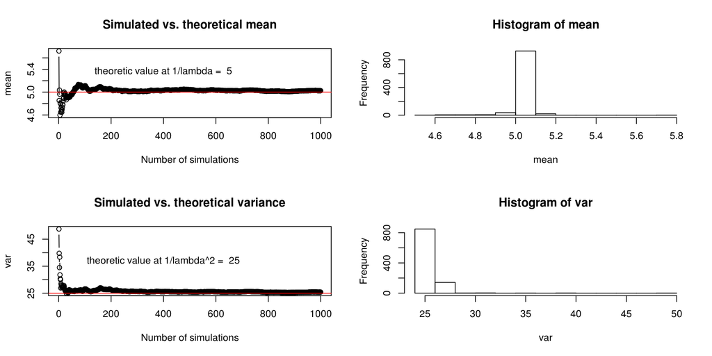

```r
set.seed(111)
rate <- 0.2
n    <- 40
s    <- 1000
X = matrix(rexp(n*s, rate=rate), length(rexp(n)),s)
mean <- cumsum(colMeans(X)) /(1:s)
var <- cumsum(apply(X,2,sd)^2)/(1:s)
par(mfrow=c(2,2))
plot(mean, type="b", main="Simulated vs. theoretical mean", xlab="Number of simulations")
abline(1/rate,0, col="red")
text(400,0.5*(max(mean)+mean(mean)), paste("theoretic value at 1/lambda = ", 1/rate))
hist(mean)
plot(var, type="b", main="Simulated vs. theoretical variance", xlab="Number of simulations")
abline(1/rate^2,0 ,col="red")
text(400,0.5*(max(var)+mean(var)), paste("theoretic value at 1/lambda^2 = ", 1/rate^2))
hist(var)
```

In the following figure we check the central limit theorem for the exponential distribution. For this we run three simulations. 1) with sample size `n =10` and `s=10` simulation runs. Then for the 2nd we multiply both by 10 also again for the third. In the figure we can see then how the shape of the distribution changes as we vary sample size and simulations. The centre of the distribution is more and more moving around the expected mean of the distribution $E\left[ X \right] = \frac{1}{\lambda} = \frac{1}{0.2} = 5$

So we find a very bell shaped normal distribution of the sampled expected mean around its theoretical expected value. We conduct a `shapiro.test` to theck the normal distribution and we find that the hypothesis that the distribution is normal cannot be rejected, so we can assume that the samples of the simulated means follow a normal distribution.

```r
set.seed(111)
n <-10
s<-10
rate <-0.2

X = matrix(rexp(n*s, rate=rate), length(rexp(n)),s)

sim10 <- as.data.frame(colMeans(X))
sim10$type <- "S10N10"
n <-100;s=100
X = matrix(rexp(n*s, rate=rate), length(rexp(n)),s)
sim100 <- as.data.frame(colMeans(X))
sim100$type <- "S100N100"
n <-1000;s=1000
X = matrix(rexp(n*s, rate=rate), length(rexp(n)),s)
sim1000 <- as.data.frame(colMeans(X))
sim1000$type <- "S1000N1000"

sim_total <- rbind(sim10,sim100,sim1000)

require(lattice)
```

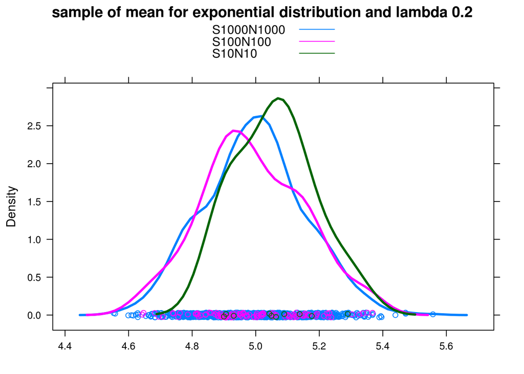

```r
densityplot(~colMeans(X), groups=factor(type), data=sim_total, auto.key=TRUE, main="sample of mean for exponential distribution and lambda 0.2", xlab="", lwd=3)
```

```r
shapiro.test(sim1000$'colMeans(X)')
```

```
##
##  Shapiro-Wilk normality test
##
## data:  sim1000$"colMeans(X)"
## W = 0.998, p-value = 0.2713
```

## Exercise 2

### Overview

The aim of this analysis is to show if there is a significant difference of two different delivery methods (orange juice or ascorbic acid) on the tooth growth. For this we use the dataset `ToothGrowth`, information on the dataset can be found `?ToothGrowth`

In an aggregated summary and boxplot we can that on first impression the average growth is higher for the orange juice, but we also see that the for ascorbic acid the variation is much higher. To get a clear answer if there is a difference between both supplements we conduct a `t.test` of the mean difference. The result of the double-sided `t.test` emphasizes that there is no significant difference between both delivery methods as we cannot reject the null hypothesis. When we draw a 95% confidence interval we can also see that zero is included in the interval, so it is not possible to find a difference that is significantly different from zero and as such there cannot be found a statistically difference in the delivery method on the tooth growth.

```r
data(ToothGrowth)
aggregate(ToothGrowth$len, by=list(supp=ToothGrowth$supp), mean)
```

```
##   supp        x
## 1   OJ 20.66333
## 2   VC 16.96333
```

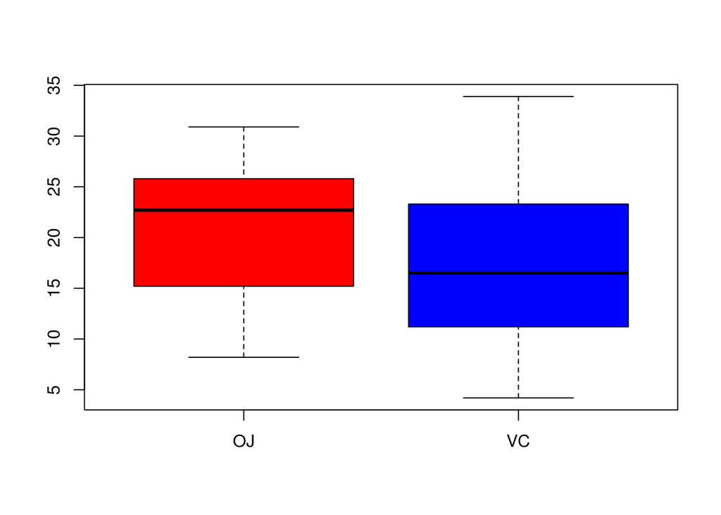

```r
boxplot(len~supp, data=ToothGrowth, col=c("red","blue"))
```

```r
t.test(len~supp, data=ToothGrowth, var.equal=FALSE)
```

```
##
##  Welch Two Sample t-test
##
## data:  len by supp
## t = 1.9153, df = 55.309, p-value = 0.06063
## alternative hypothesis: true difference in means is not equal to 0
## 95 percent confidence interval:
##  -0.1710156  7.5710156
## sample estimates:
## mean in group OJ mean in group VC
##         20.66333         16.96333
```

```r
t.test(len~supp, data=ToothGrowth, var.equal=FALSE)$conf
```

```
## [1] -0.1710156  7.5710156
## attr(,"conf.level")
## [1] 0.95
```